Machine Learning · Ensemble Methods · R

# Ensemble Methods for Sales Prediction

Comparing bagging, random forests, gradient boosting, elastic net, and model stacking for predicting car seat sales from retail and product attributes using the Carseats dataset.

Bagged Trees Random Forest Gradient Boosting Elastic Net Stacked Ensemble

## Dataset Overview

The **Carseats** dataset from the ISLR package contains 400 observations across 11 variables, capturing simulated car seat sales at child car seat retail locations. The prediction target is `Sales` (unit sales in thousands). Predictors include competitor pricing, income, advertising spend, population, shelf location quality, and demographic features.

```
library(visdat)
vis_dat(Carseats) + theme(axis.text.x = element_text(hjust = 0.5))
```

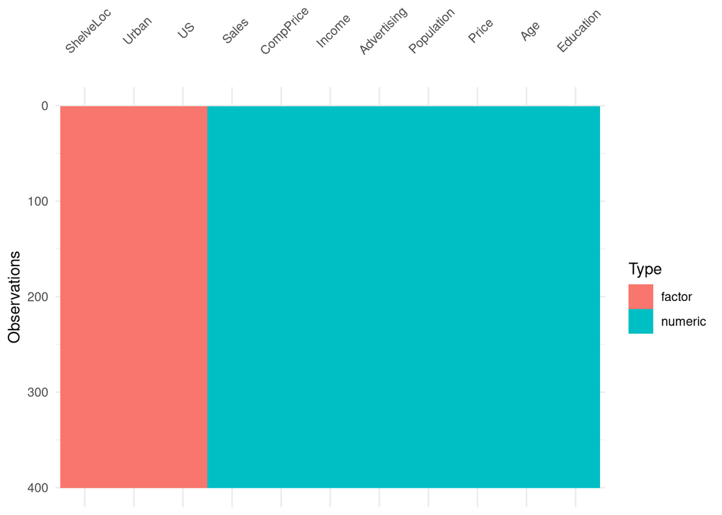

Figure 1. Variable types in the Carseats dataset: 8 numeric and 3 factor variables (ShelveLoc, Urban, US). No missing data.

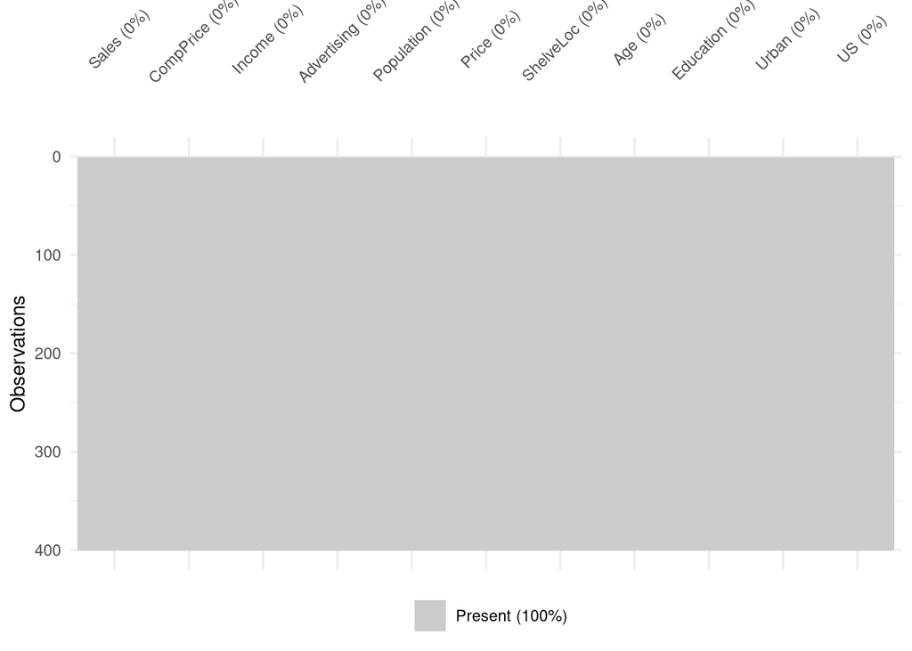

Figure 2. Missing data check — 0% missing values confirmed across all variables.

There are no missing values in the Carseats dataset. The three factor variables (ShelveLoc, Urban, US) will be one-hot encoded during preprocessing; all numeric predictors will be standardized to ensure comparability across methods that are sensitive to scale differences (particularly elastic net).

### Sales Distribution

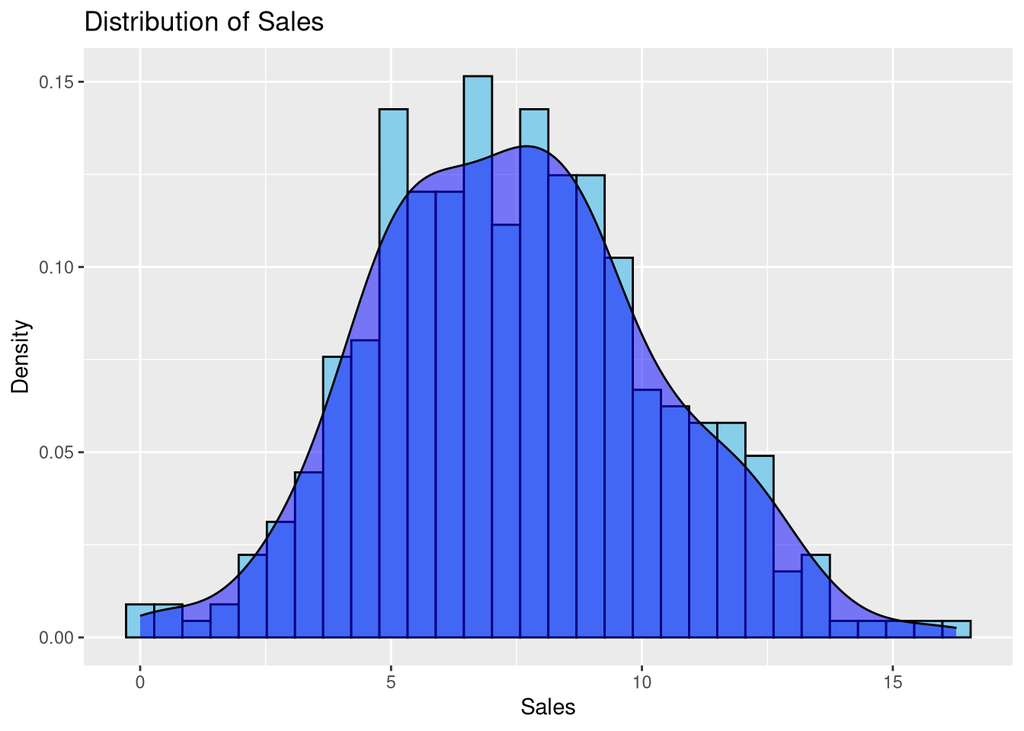

Figure 3. Distribution of car seat Sales (thousands of units). The distribution is approximately bell-shaped, centered around 7–8 thousand units.

### Preprocessing Recipe

A unified preprocessing recipe was created for all four model families. Dummy encoding and normalization ensure compatibility across tree-based methods and penalized regression:

```
sales_rec <- recipe(Sales ~ ., data = Carseats) |>
  step_dummy(all_nominal_predictors()) |>
  step_normalize(all_predictors())

base_wf <- workflow() |> add_recipe(sales_rec)
```

## Model 1: Bagged Decision Trees

Bagging (Bootstrap Aggregating) fits multiple decision trees on bootstrapped samples of the training data and averages their predictions. By using all available predictors at each split (`mtry = ncol(Carseats) - 1 = 10`), bagging reduces variance while maintaining low bias. The number of trees was tuned from (10, 25, 50, 100, 200, 300).

```
set.seed(7)
carseats_folds <- vfold_cv(Carseats, v = 5)

bag_spec <- rand_forest(trees = tune(),
                        mtry = ncol(Carseats) - 1,
                        engine = 'ranger',
                        mode = 'regression')

bagged_results <- tune_grid(bagged_wf,
                            grid = trees_grid,
                            resamples = carseats_folds,
                            control = ctrl)
```

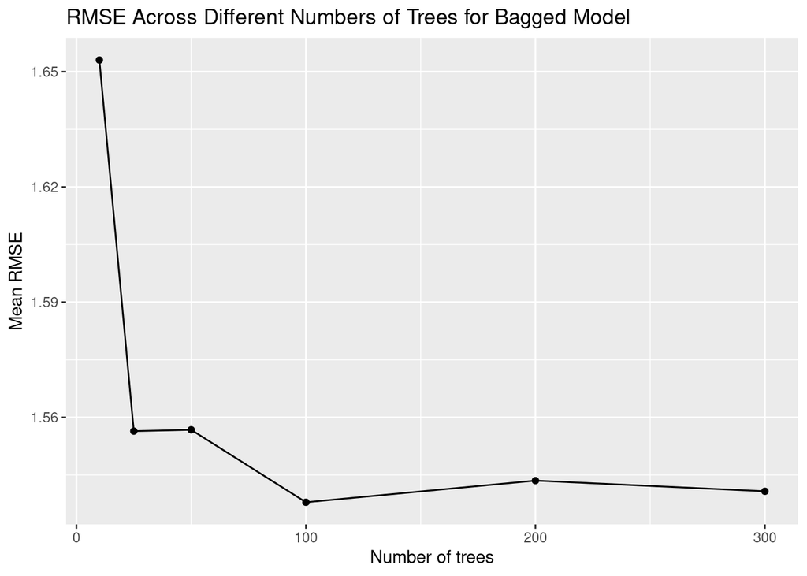

Figure 4. Mean CV RMSE versus number of trees for bagged decision trees. RMSE drops sharply from 10 to 50 trees, stabilizes around 100, and shows minimal improvement beyond that.

Best: trees = 100 | CV RMSE = 1.54

## Model 2: Random Forest

Random forest extends bagging by randomly sampling a subset of predictors at each split decision (`mtry < total predictors`). This decorrelates the individual trees, further reducing variance. The same tree count grid was applied.

```
rf_spec <- rand_forest(trees = tune()) |>
  set_engine("ranger") |>
  set_mode("regression")
```

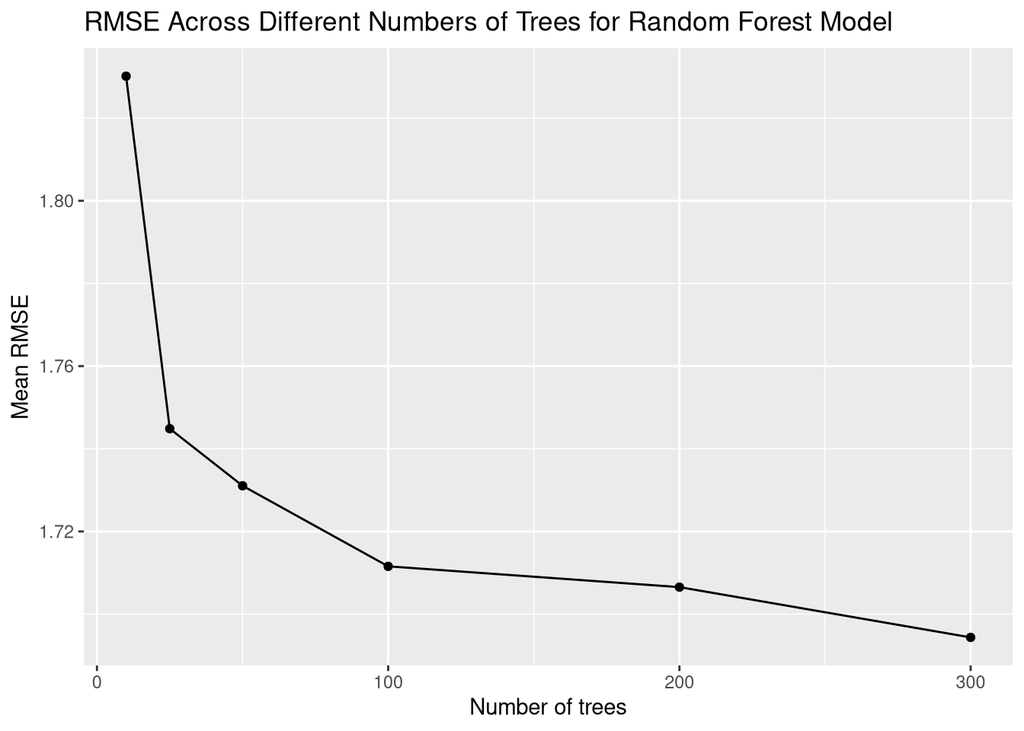

Figure 5. Mean CV RMSE versus number of trees for random forest. Performance improves steadily through 300 trees, unlike bagging which plateaued earlier.

## Model 3: Gradient Boosted Trees

Gradient boosting (XGBoost) builds trees sequentially, with each tree fitted to the residuals of the previous ensemble. The tree depth was fixed at 1 (stumps) with a learning rate of 0.1, and the number of boosting rounds was tuned. The sequential, additive nature of boosting makes it particularly effective at capturing complex patterns.

```
boost_spec <- boost_tree(tree_depth = 1,
                         learn_rate = 0.1,
                         trees = tune()) |>
  set_engine("xgboost") |>
  set_mode("regression")
```

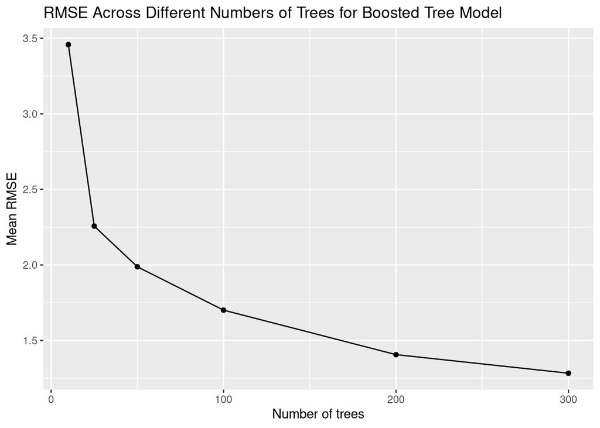

Figure 6. Mean CV RMSE versus number of trees for gradient boosting. Unlike bagging/random forest, RMSE continues declining monotonically through 300 trees with no sign of plateauing—suggesting even more trees may improve performance.

Best: trees = 300 | CV RMSE = 1.28

## Model 4: Elastic Net

Elastic net combines L1 and L2 regularization and served as a linear baseline. Despite its simplicity relative to tree-based methods, it performed competitively—evidence that the Carseats data has a strong linear structure. Both penalty λ and mixture α were tuned simultaneously.

```
grid <- expand_grid(
  penalty = seq(0, 0.1, by = 0.01),
  mixture = c(0, 0.5, 1)
)
```

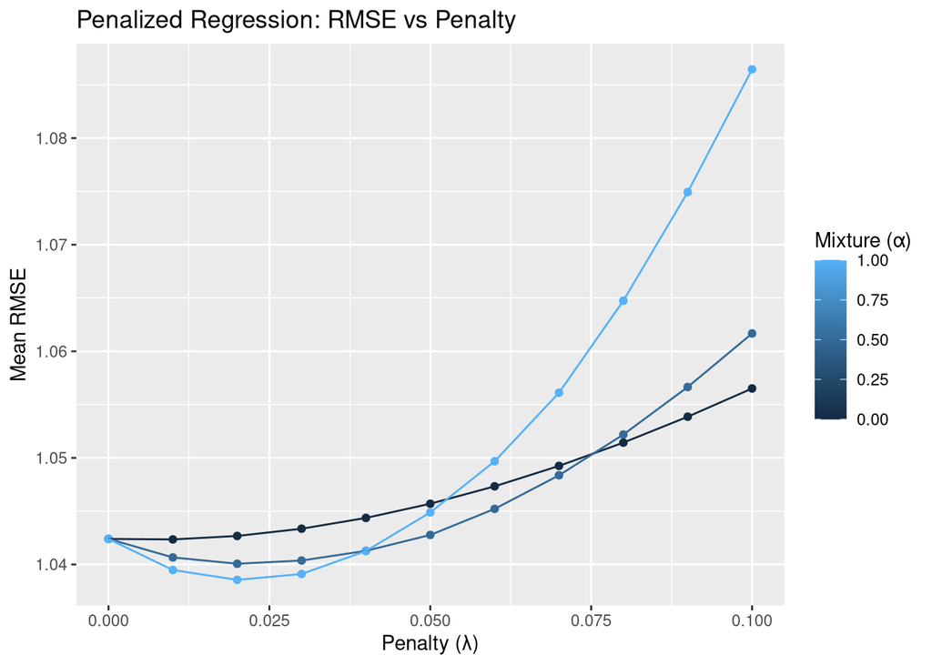

Figure 7. CV RMSE versus penalty strength for elastic net across mixture values. Lower penalties and higher mixture (lasso) values achieve the best performance.

Best: penalty = 0.02, mixture = 1.0 | CV RMSE = 1.04

## Individual Model Comparison

Bagged Trees

Best: 100 trees

RMSE 1.54

Random Forest

RMSE 1.69

Gradient Boosting

Best: 300 trees

RMSE 1.28

Elastic Net

Best: λ=0.02, α=1

RMSE 1.04

Elastic net substantially outperforms all tree-based methods (RMSE 1.04 vs. 1.28–1.69). This is likely because the Carseats data has strong linear structure—elastic net's regularization efficiently exploits this while tree methods need more observations to recover linear patterns through splits.

## Model Stacking: The Final Ensemble

A stacked ensemble was constructed using the `stacks` package, combining all four model families. The stacking algorithm applies regularization over the candidate member predictions to find an optimal linear combination.

```
ens <- stacks() |>
  add_candidates(bagged_results) |>
  add_candidates(rf_tuned_results) |>
  add_candidates(boost_tuned_results) |>
  add_candidates(elas) |>
  blend_predictions() |>
  fit_members()
```

── A stacked ensemble model ────────────────────────────── Out of 51 possible candidate members, the ensemble retained 5. Penalty: 1e-06 | Mixture: 1 # A tibble: 5 × 3 member type weight 1 elas_1_27 linear_reg 0.357 2 elas_1_28 linear_reg 0.290 3 elas_1_29 linear_reg 0.239 4 elas_1_26 linear_reg 0.114 5 elas_1_30 linear_reg 0.059

### Stacking Results

The ensemble retained only 5 members from 51 candidates—all from the elastic net family. This confirms that elastic net variants captured the most signal in the data. The stacking weights assign the highest importance to the elastic net model with penalty ≈ 0.04 (weight 0.357), with diminishing contributions from higher-penalty variants.

[output not shown]